# NHBE IAV Seurat Analysis

2023-06-30

## Read in PIPseq data and Run SoupX to remove multiplets

Here we use SoupX to infer contamination with influenza genes as markers, this allows focus on influenza as the determining factor not cell-type. Refer to [this paper](https://journals.plos.org/plospathogens/article?id=10.1371/journal.ppat.1010943#sec009) for detailed description.

Additional SoupX description can be found [here](https://rawcdn.githack.com/constantAmateur/SoupX/204b602418df12e9fdb4b68775a8b486c6504fe4/inst/doc/pbmcTutorial.html).

For count adjustment, the `method` parameter controls how the removal of counts in performed. This should almost always be left at the default (‘subtraction’), which iteratively subtracts counts from all genes as described above. The ‘soupOnly’ method will use a p-value based estimation procedure to identify those genes that can be confidently identified as having endogenous expression and removes everything else (described in greater detail below). Because this method either removes all or none of the expression for a gene in a cell, the correction procedure is much faster. Finally, the ‘multinomial’ method explicitly maximises the multinomial likelihood for each cell. This method gives essentially identical results as ‘subtraction’ and is considerably slower.

```r
RunSoupX = function (dir, name){
  toc = Seurat::Read10X(data.dir = paste0(dir, "filtered_matrix/sensitivity_5/"))
  tod = Seurat::Read10X(data.dir = paste0(dir, "raw_matrix/"))
  sc = SoupChannel(tod, toc)
  useToEst = estimateNonExpressingCells(sc, nonExpressedGeneList = list(Vir), clusters= F)
  sc = calculateContaminationFraction(sc, list(Vir), useToEst = useToEst)
  out = adjustCounts(sc)
  return(CreateSeuratObject(out, project = name))
}
```

```r
# data_dir="~/OneDrive - Fred Hutchinson Cancer Research Center/Personal_OneDrive_BlancoMeloLab/Projects/NS1_priority/scRNAseq/out/NHBE_IAV30T/"
# NHBE_IAV30T=RunSoupX(data_dir, "NHBE_IAV30T")
#
# data_dir="~/OneDrive - Fred Hutchinson Cancer Research Center/Personal_OneDrive_BlancoMeloLab/Projects/NS1_priority/scRNAseq/out/NHBE_IAVWT/"
# NHBE_IAVWT=RunSoupX(data_dir, "NHBE_IAVWT")
#
# obj.combined=list(NHBE_IAV30T, NHBE_IAVWT)
#
# saveRDS(obj.combined, file="./seurat_objects_soupX_corrected.rds")

obj.combined = readRDS(file="./seurat_objects_soupX_corrected.rds")

NHBE_IAVWT=obj.combined[[2]]
```

## Initial Data Filtering

```r
NHBE_IAVWT <- PercentageFeatureSet(NHBE_IAVWT, pattern = "^MT-", col.name = "percent.mt")
NHBE_IAVWT<- PercentageFeatureSet(NHBE_IAVWT, pattern = "^RP[SL]", col.name = "percent.ribo")
NHBE_IAVWT <- PercentageFeatureSet(NHBE_IAVWT, features = Vir, col.name = "percent.viral")
```

Visualize the input sample, which is already filtered through PIPSeeker at sensitivity 5, and soupX

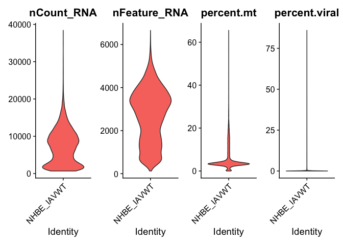

```r
VlnPlot(NHBE_IAVWT, features=c("nCount_RNA", "nFeature_RNA",
                                "percent.mt", "percent.viral"),
        pt.size=0,
        ncol=4,
        log=F)
```

```r
percent_mito <- 10
NHBE_IAVWT <- subset(NHBE_IAVWT, subset = percent.mt < percent_mito)
NHBE_IAVWT <- subset(NHBE_IAVWT, subset =  nCount_RNA > 2500 &  nCount_RNA < 25000)
```

Visualize basic parameters again to ensure the filtered cells look correct

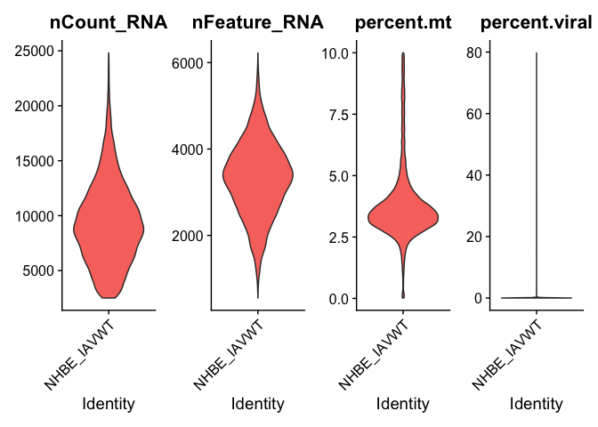

```r
VlnPlot(NHBE_IAVWT, features=c("nCount_RNA", "nFeature_RNA",
                                "percent.mt", "percent.viral"),
        pt.size=0,
        ncol=4,
        log=F)
```